# Experiment #11 - Feature Engineering

## Overview

The purpose of this notebook is to improve the performance of the baseline model by creating derived features for the best classifier. So, our first task is to analyze the predictions from the baseline ML models.

```python
%load_ext autoreload
%autoreload 2

from utils import code
from plot_libraries import setup_graphics
from datasets import get_data
```

```python
#Main Libraries
import os, random, re, sys, warnings
import numpy as np
import pandas as pd
import matplotlib.pyplot as plt
import seaborn as sns
from joblib import load

#utils
from plot_libraries import setup_graphics, dist_plot

#corr matrix
from scipy.stats import spearmanr
from scipy.cluster import hierarchy
from sklearn.inspection import permutation_importance

#Data transform (pipeline)
from sklearn.preprocessing import OneHotEncoder, FunctionTransformer, LabelEncoder, OrdinalEncoder
from sklearn.preprocessing import MinMaxScaler,RobustScaler
from sklearn.compose import ColumnTransformer
from sklearn.pipeline import Pipeline, FeatureUnion
from sklearn.impute import SimpleImputer
from sklearn.model_selection import train_test_split, cross_val_predict
from sklearn.calibration import CalibratedClassifierCV



# Model evaluation
import scikitplot as skplt
from sklearn.metrics import make_scorer, roc_auc_score, brier_score_loss, classification_report, confusion_matrix
from sklearn.model_selection import train_test_split, cross_val_predict
from evaluation import plot_learning_curve, evaluate_model, plot_confusion_matrix
from evaluation import plot_feature_permutation, plot_calibration_curve, get_cv_scores


# Support
import parameters as params
from model import Model, build_tuned_model
from datasets import get_data
from experiments import experiment_1, experiment_2, get_scorer, experiment_11
from sklearn.metrics import make_scorer, roc_auc_score, brier_score_loss, classification_report, confusion_matrix

#setup
warnings.filterwarnings("ignore")
pd.options.display.max_columns = None
sns.set()
%matplotlib inline
setup_graphics()
```

```python
X, y = get_data('../data/trainDF.csv')
X_train, X_test, y_train, y_test = train_test_split(X, y, test_size=.2, stratify=y, random_state=20)
```

```python
model = Model.load('../models_pkl/experiment-1-model.pkl')
pipeline1 = experiment_1.get_full_pipeline()
```

We noticed that the feature importance of our model is biased due 2 reasons:

- `Activities_Last_30_Days`: Has a leaky beahaviour and must be removed in order to does not harn predictions od future data
- High correlated variables which decrease the importance amog them.

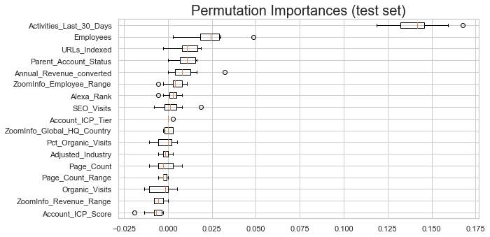

```python
plot_feature_permutation(pipeline1, model.model, X_train, y_train, X_test, y_test)
```

### Pipeline Experiment 11

```python
pipeline11 = experiment_11.get_full_pipeline()
ps = pipeline11.fit_transform(X_train).shape
print('Instances: {:,}, Features: {}'.format(ps[0], ps[1]))
```

```
Instances: 1,479, Features: 62
```

```python
#setup
scorer = make_scorer(roc_auc_score)
results, res_cv, res_calibrated, n_iter = list(), dict(), dict(), 100
```

#### ML Models (+pipeline 11)

**Logistic Regression**

- Exp 1.0 - best lr score (AUC): `0.653`
- Exp 1.1 - best lr score (AUC): `0.856`
- Exp 1.1 - Precision C1: `0.53`
- Exp 1.1 (Iso) - best lr score (AUC): `0.852`
- Exp 1.1 (Iso) - Precision C1: `0.686`

```
==> Starting 5-fold cross validation for lr model, 1479 examples
Fitting 5 folds for each of 100 candidates, totalling 500 fits
```

```
[Parallel(n_jobs=-1)]: Using backend LokyBackend with 4 concurrent workers.
[Parallel(n_jobs=-1)]: Done  12 tasks      | elapsed:    0.5s
[Parallel(n_jobs=-1)]: Done 120 tasks      | elapsed:    2.9s
[Parallel(n_jobs=-1)]: Done 300 tasks      | elapsed:    6.8s
[Parallel(n_jobs=-1)]: Done 493 out of 500 | elapsed:   11.0s remaining:    0.2s
[Parallel(n_jobs=-1)]: Done 500 out of 500 | elapsed:   11.2s finished
```

[output not shown]

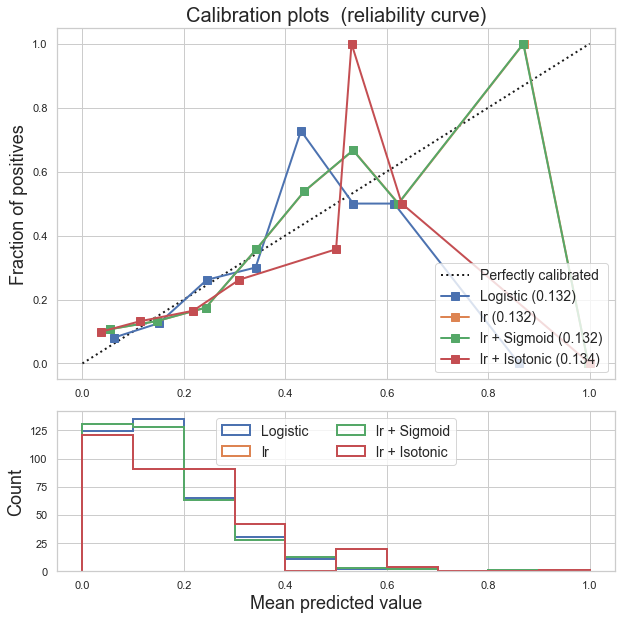

```python
from sklearn.linear_model import LogisticRegression
lr_param_grid = {
  'lr__C': np.logspace(-3, 2, 6),
  'lr__intercept_scaling': [1],
  'lr__max_iter': [100],
  'lr__penalty':  ['l1', 'l2'],
  'lr__solver': ['liblinear'], #good for small datasets
  'lr__tol': [0.0001],
  'lr__class_weight': [None, {0:1,1:1}, {0:1,1:10}, {0:1,1:100}, 'balanced']

}


#0.694
result = evaluate_model(X_train, y_train, 'lr',
                        LogisticRegression(),
                        lr_param_grid,
                        scorer, n_iter=n_iter,
                        cv_folds=5, pipeline=pipeline11)
results.append(result)
res_cv[result[1]] = get_cv_scores(result[0])
res_calibrated[result[1]] = plot_calibration_curve(result[0], X_train, X_test, y_train, y_test, False)
```

**SGD Classifier**

- Exp 1.0 - best sgd score (AUC): `0.678`
- Exp 1.1 - best sgd score (AUC): `0.862`
- Exp 1.1 - Precision C1: `0.430`
- Exp 1.1 (Iso) - best sgd score (AUC): `0.864`
- Exp 1.1 (Iso) - Precision C1: `0.759`

```
==> Starting 5-fold cross validation for sgd model, 1479 examples
Fitting 5 folds for each of 100 candidates, totalling 500 fits
```

```
[Parallel(n_jobs=-1)]: Using backend LokyBackend with 4 concurrent workers.
[Parallel(n_jobs=-1)]: Done  12 tasks      | elapsed:    0.5s
[Parallel(n_jobs=-1)]: Done 120 tasks      | elapsed:    3.2s
[Parallel(n_jobs=-1)]: Done 300 tasks      | elapsed:    7.7s
[Parallel(n_jobs=-1)]: Done 493 out of 500 | elapsed:   13.7s remaining:    0.2s
[Parallel(n_jobs=-1)]: Done 500 out of 500 | elapsed:   13.8s finished
```

```
==> Elapsed seconds: 13.850
Best sgd model: SGDClassifier(alpha=0.001, average=False, class_weight='balanced',
              early_stopping=False, epsilon=0.1, eta0=0.0, fit_intercept=True,
              l1_ratio=0.15, learning_rate='optimal', loss='log', max_iter=1000,
              n_iter_no_change=5, n_jobs=-1, penalty='l1', power_t=0.5,
              random_state=None, shuffle=True, tol=0.001,
              validation_fraction=0.1, verbose=0, warm_start=False)
Best sgd score (val): 0.648

======== sgd (test):
>Brier Score: 0.208
>ROC AUC: 0.658
>Precision class 1: 0.270
              precision    recall  f1-score   support

           0       0.87      0.73      0.79       307
           1       0.27      0.49      0.35        63

    accuracy                           0.69       370
   macro avg       0.57      0.61      0.57       370
weighted avg       0.77      0.69      0.72       370

Confusion matrix:
[[223  84]
 [ 32  31]]


======== sgd + Isotonic (test):
>Brier Score: 0.135
>ROC AUC: 0.659
>Precision class 1: 0.750
              precision    recall  f1-score   support

           0       0.84      1.00      0.91       307
           1       0.75      0.05      0.09        63

    accuracy                           0.84       370
   macro avg       0.79      0.52      0.50       370
weighted avg       0.82      0.84      0.77       370

Confusion matrix:
[[306   1]
 [ 60   3]]
```

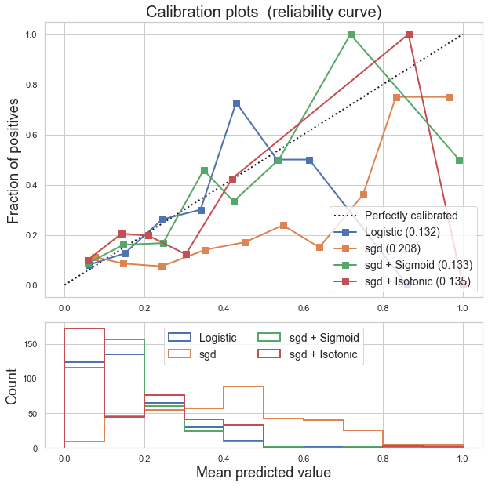

```python
from sklearn.linear_model import SGDClassifier
sgd_param_grid = {
  'sgd__alpha' : np.logspace(-4, 3, 8),
  'sgd__loss' : ['log'], #['log','hinge'],
  'sgd__max_iter' : [1000],
  'sgd__n_jobs' : [-1],
  'sgd__penalty' : ['l2', 'l1', 'elasticnet'],
  'sgd__tol' : [0.001],
  'sgd__class_weight': [None, {0:1,1:1}, {0:1,1:10}, {0:1,1:100}, 'balanced']
}

#0.694=>0.747
result = evaluate_model(X_train, y_train, 'sgd',
                        SGDClassifier(),
                        sgd_param_grid,
                        scorer, n_iter=n_iter,
                        cv_folds=5, pipeline=pipeline11)
results.append(result)
res_cv[result[1]] = get_cv_scores(result[0])
res_calibrated[result[1]] = plot_calibration_curve(result[0], X_train, X_test, y_train, y_test, False)
```

**XGBoost**

- Exp 1.0 - best xgb score (AUC): `0.753`
- Exp 1.1 - best xgb score (AUC): `0.908`
- Exp 1.1 - Precision C1: `0.585`
- Exp 1.1 (Iso) - best xgb score (AUC): `0.826`
- Exp 1.1 (Iso) - Precision C1: `0.720`

```
==> Starting 5-fold cross validation for xgb model, 1479 examples
Fitting 5 folds for each of 100 candidates, totalling 500 fits
```

```
[Parallel(n_jobs=-1)]: Using backend LokyBackend with 4 concurrent workers.
[Parallel(n_jobs=-1)]: Done  10 tasks      | elapsed:    2.6s
[Parallel(n_jobs=-1)]: Done  64 tasks      | elapsed:   16.0s
[Parallel(n_jobs=-1)]: Done 154 tasks      | elapsed:   38.6s
[Parallel(n_jobs=-1)]: Done 280 tasks      | elapsed:  1.3min
[Parallel(n_jobs=-1)]: Done 442 tasks      | elapsed:  2.2min
[Parallel(n_jobs=-1)]: Done 500 out of 500 | elapsed:  2.4min finished
```

```
==> Elapsed seconds: 147.774
Best xgb model: XGBClassifier(base_score=0.5, booster=None, colsample_bylevel=0.7,
              colsample_bynode=1, colsample_bytree=0.7, gamma=0.05, gpu_id=-1,
              importance_type='gain', interaction_constraints=None,
              learning_rate=0.1, max_delta_step=0, max_depth=24,
              min_child_weight=9, missing=nan, monotone_constraints=None,
              n_estimators=350, n_jobs=0, num_parallel_tree=1,
              objective='binary:logistic', random_state=0,
              reg_alpha=0.01668100537200059, reg_lambda=0.01,
              scale_pos_weight=3000, subsample=0.8, tree_method=None,
              validate_parameters=False, verbosity=None)
Best xgb score (val): 0.752

======== xgb (test):
>Brier Score: 0.202
>ROC AUC: 0.742
>Precision class 1: 0.333
              precision    recall  f1-score   support

           0       0.89      0.79      0.83       307
           1       0.33      0.52      0.41        63

    accuracy                           0.74       370
   macro avg       0.61      0.65      0.62       370
weighted avg       0.79      0.74      0.76       370

Confusion matrix:
[[241  66]
 [ 30  33]]


======== xgb + Isotonic (test):
>Brier Score: 0.141
>ROC AUC: 0.603
>Precision class 1: 0.846
              precision    recall  f1-score   support

           0       0.85      0.99      0.92       307
           1       0.85      0.17      0.29        63

    accuracy                           0.85       370
   macro avg       0.85      0.58      0.60       370
weighted avg       0.85      0.85      0.81       370

Confusion matrix:
[[305   2]
 [ 52  11]]
```

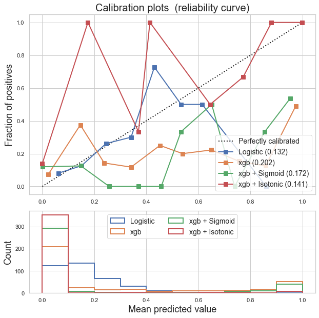

```python
from xgboost import XGBClassifier
xgb_param_grid = {
        'xgb__colsample_bylevel' : [0.1, 0.2, 0.3, 0.4, 0.5, 0.6, 0.7, 0.8, 1.0],
        'xgb__colsample_bytree' :[0.6, 0.7, 0.8, 1.0],
        'xgb__gamma' : list(np.linspace(0.05, 1, 6)),
        'xgb__learning_rate' : [0.0001, 0.001, 0.01, 0.1, 0.2, 0.3],
        'xgb__max_depth' : list(range(3, 30, 3)),
        'xgb__min_child_weight' : list(range(1, 11, 2)),
        'xgb__n_estimators' : list(range(50, 400, 50)),
        'xgb__reg_alpha' : list(np.logspace(-1, 1, num=10)/10),
        'xgb__reg_lambda' : list(np.logspace(-1, 1, num=10)/10),
        'xgb__subsample' : [0.6, 0.7, 0.8, 1.0],
        'xgb__scale_pos_weight' : [1, 10, 25, 50, 75, 99, 100, 1000, 3000,5000, 10000]


}

#0.829
result = evaluate_model(X_train, y_train, 'xgb',
                        XGBClassifier(),
                        xgb_param_grid,
                        scorer, n_iter=n_iter,
                        cv_folds=5, pipeline=pipeline11)
results.append(result)
res_cv[result[1]] = get_cv_scores(result[0])
res_calibrated[result[1]] = plot_calibration_curve(result[0], X_train, X_test, y_train, y_test, False)
```

**Light GBM**

- Exp 1.0 - best lgbm score (AUC): `0.808`
- Exp 1.1 - best lgbm score (AUC): `0.897`
- Exp 1.1 - Precision C1: `0.520`
- Exp 1.1 (Iso) - best lgbm score (AUC): `0.810`
- Exp 1.1 (Iso) - Precision C1: `0.723`

```
==> Starting 5-fold cross validation for lgbm model, 1479 examples
Fitting 5 folds for each of 100 candidates, totalling 500 fits
```

```
[Parallel(n_jobs=-1)]: Using backend LokyBackend with 4 concurrent workers.
[Parallel(n_jobs=-1)]: Done  10 tasks      | elapsed:    0.7s
[Parallel(n_jobs=-1)]: Done  64 tasks      | elapsed:    4.4s
[Parallel(n_jobs=-1)]: Done 154 tasks      | elapsed:    9.8s
[Parallel(n_jobs=-1)]: Done 280 tasks      | elapsed:   16.4s
[Parallel(n_jobs=-1)]: Done 442 tasks      | elapsed:   25.3s
[Parallel(n_jobs=-1)]: Done 500 out of 500 | elapsed:   28.2s finished
```

```
==> Elapsed seconds: 28.384
Best lgbm model: LGBMClassifier(boosting_type='dart', class_weight={0: 1, 1: 1},
               colsample_bytree=0.6888888888888889, importance_type='split',
               is_unbalance=False, learning_rate=0.14806127189940171,
               max_depth=-1, min_child_samples=50, min_child_weight=0.001,
               min_split_gain=0.0, n_estimators=100, n_jobs=-1, num_leaves=136,
               objective=None, random_state=None, reg_alpha=0.22448979591836732,
               reg_lambda=0.8775510204081632, silent=True,
               subsample=0.6111111111111112, subsample_for_bin=40000,
               subsample_freq=0)
Best lgbm score (val): 0.719

======== lgbm (test):
>Brier Score: 0.123
>ROC AUC: 0.732
>Precision class 1: 0.625
              precision    recall  f1-score   support

           0       0.86      0.97      0.91       307
           1       0.62      0.24      0.34        63

    accuracy                           0.85       370
   macro avg       0.74      0.60      0.63       370
weighted avg       0.82      0.85      0.82       370

Confusion matrix:
[[298   9]
 [ 48  15]]


======== lgbm + Isotonic (test):
>Brier Score: 0.147
>ROC AUC: 0.703
>Precision class 1: 0.526
              precision    recall  f1-score   support

           0       0.87      0.94      0.90       307
           1       0.53      0.32      0.40        63

    accuracy                           0.84       370
   macro avg       0.70      0.63      0.65       370
weighted avg       0.81      0.84      0.82       370

Confusion matrix:
[[289  18]
 [ 43  20]]
```

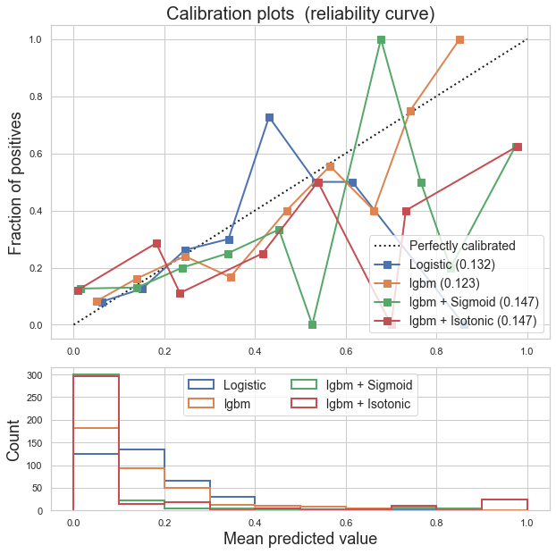

```python
from lightgbm import LGBMClassifier
lgbm_param_grid = {
    'lgbm__boosting_type': ['gbdt', 'goss', 'dart'],
    'lgbm__num_leaves': list(range(20, 150)),
    'lgbm__learning_rate': list(np.logspace(np.log10(0.005), np.log10(0.5), base = 10, num = 1000)),
    'lgbm__subsample_for_bin': list(range(20000, 300000, 20000)),
    'lgbm__min_child_samples': list(range(20, 500, 5)),
    'lgbm__reg_alpha': list(np.linspace(0, 1)),
    'lgbm__reg_lambda': list(np.linspace(0, 1)),
    'lgbm__colsample_bytree': list(np.linspace(0.6, 1, 10)),
    'lgbm__subsample': list(np.linspace(0.5, 1, 100)),
    'lgbm__is_unbalance': [True, False],
    'lgbm__class_weight': [None, {0:1,1:1}, {0:1,1:10}, {0:1,1:100}, 'balanced']

}


#0.811=>0.822
result = evaluate_model(X_train, y_train, 'lgbm',
                        LGBMClassifier(),
                        lgbm_param_grid,
                        scorer, n_iter=n_iter,
                        cv_folds=5, pipeline=pipeline11)
results.append(result)
res_cv[result[1]] = get_cv_scores(result[0])
res_calibrated[result[1]] = plot_calibration_curve(result[0], X_train, X_test, y_train, y_test, False)
```

### Comparing results

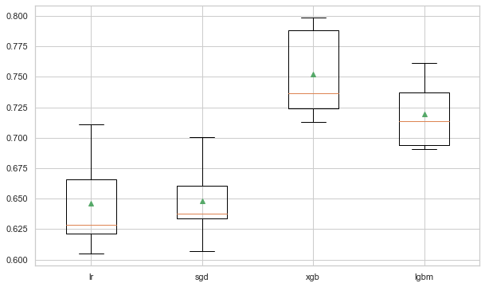

```python
_ = plt.boxplot(res_cv.values(), labels=res_cv.keys(), showmeans=True)
```

##### Calibrated Results

```python
pd.DataFrame.from_dict(list(map(lambda x:
                      {'model': res_calibrated[x][1], 'mean': res_calibrated[x][2], 'precision_c1': res_calibrated[x][3]},
                                res_calibrated)))[['model', 'mean', 'precision_c1'
                                ]].sort_values('mean', ascending=False)#.style.bar()
```

[output not shown]

The best model was **Light GBM**. We will save it to use later on.

```python
model = list(filter(lambda x: x[1] == 'lgbm', results))[0][0]
cal_model = res_calibrated['lgbm']
print('Best calibrated model performance mean:', cal_model[2])
print('Best calibrated model performance C1:', cal_model[3])
model.save('../models_pkl/experiment-1.11-model.pkl')
```

```
Best calibrated model performance mean: 0.7033762473501888
Best calibrated model performance C1: 0.5263157894736842
```

### Analyzing best model

```python
model = Model.load('../models_pkl/experiment-1.11-model.pkl')
model = list(filter(lambda x: x[1] == 'lgbm', results))[0][0]
model.model
```

```
LGBMClassifier(boosting_type='dart', class_weight={0: 1, 1: 1},
               colsample_bytree=0.6888888888888889, importance_type='split',
               is_unbalance=False, learning_rate=0.14806127189940171,
               max_depth=-1, min_child_samples=50, min_child_weight=0.001,
               min_split_gain=0.0, n_estimators=100, n_jobs=-1, num_leaves=136,
               objective=None, random_state=None, reg_alpha=0.22448979591836732,
               reg_lambda=0.8775510204081632, silent=True,
               subsample=0.6111111111111112, subsample_for_bin=40000,
               subsample_freq=0)
```

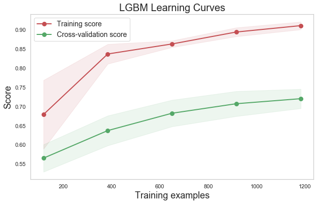

```python
plot_learning_curve(model.model,
                    model.name.upper()+' Learning Curves',
                    model.pipeline.fit_transform(X_train), y_train,
                    cv=5, scoring=scorer)
```

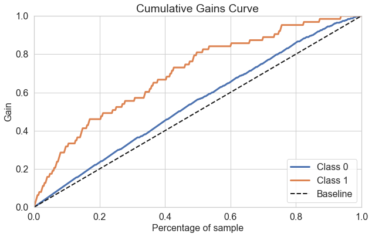

```python
preds, probs = model.predict_calibrated(X_test, X, y)
_ = skplt.metrics.plot_cumulative_gain(y_test, probs)
```

```
              precision    recall  f1-score   support

           0       0.87      0.94      0.91       307
           1       0.54      0.33      0.41        63

    accuracy                           0.84       370
   macro avg       0.71      0.64      0.66       370
weighted avg       0.82      0.84      0.82       370
```

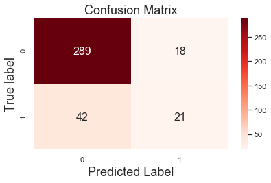

```python
plot_confusion_matrix(y_test, preds)
```

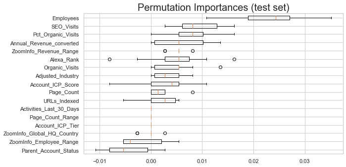

```python
plot_feature_permutation(pipeline11, model.model, X_train, y_train, X_test, y_test)
```

### Financial Impact of the Best Model

```python
n_instances = len(X)
p_instances = y.sum() / len(y)
p_targeted = 0.1
n_targeted = int(n_instances*p_targeted)
n_targeted_test = int(len(X_test) * p_targeted)
```

```
              precision    recall  f1-score   support

         0.0       0.00      0.00      0.00        18
         1.0       0.51      1.00      0.68        19

    accuracy                           0.51        37
   macro avg       0.26      0.50      0.34        37
weighted avg       0.26      0.51      0.35        37
```

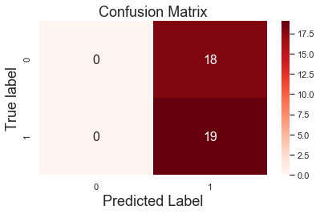

```python
# Create a dataframe of probabilities and actual / predicted outcomes
probs_df = pd.DataFrame(np.hstack([probs, y_test.values.reshape(-1,1), preds.reshape(-1,1)]),
                        columns=['p_no', 'p_yes', 'actual', 'predicted'])


# Sort customers by the probability that they will convert
model_targets = probs_df.sort_values('p_yes', ascending=False)

# Take the top 10%
model_targets = model_targets.head(n_targeted_test)

# Calculate precision matrix
plot_confusion_matrix(model_targets.actual, model_targets.predicted)
```

```python
# Setup costs and benefits
avg_revenue = params.AVG_REVENUE
avg_cost = params.AVG_COST

# Calculate financial outcomes
random_profit = experiment_1.get_model_profit(X_test, y_test, n_targeted_test, avg_revenue, avg_cost, experiment_1.random_model_predictions)
baseline_profit = experiment_1.get_model_profit(X_test, y_test, n_targeted_test, avg_revenue, avg_cost, experiment_1.baseline_model_predictions)
model_profit = experiment_1.get_model_profit(X_test, y_test, n_targeted_test, avg_revenue, avg_cost, preds=model_targets.actual)

print('Number of customers targeted: {:,}/{:,}'.format(len(model_targets), len(X_test)))
print('Conversion rate of model policy: {:.2f}%'.format(model_targets.actual.sum() / len(y_test)*100.))
print('Expected profit of model policy: ${:,}'.format(model_profit))
print('Lift over random: {:.1f} or ${:,}'.format(model_profit / random_profit, model_profit - random_profit))
print('Lift over baseline: {:.1f} or ${:,}'.format(model_profit / baseline_profit, model_profit - baseline_profit))
```

```
Number of customers targeted: 37/370
Conversion rate of model policy: 5.14%
Expected profit of model policy: $18,630
Lift over random: 3.3 or $13,000
Lift over baseline: 1.5 or $6,000
```